# SHINE_color: controlling low-level properties of colorful images

26 June 2023

# Abstract

Visual perception combines top-down processes arising from participants individual histories, such as expectations and goals, and bottom-up processes that arise from visual stimuli properties, such as luminance and contrast. The precise control of low-level visual stimuli properties is essential when investigating visual perception. Without it, for instance, investigations of bottom-up processes are virtually impossible and investigations of top-down processes risk major confounds when testing and formulating hypotheses. The SHINE (spectrum, histogram, and intensity normalization and equalization) toolbox for MATLAB (Willenbockel et al. 2010) allows precise control of images’ Fourier amplitude spectra, the normalizing and scaling of luminance and contrast, and exact histogram specification optimized for perceptual visual quality. Following Willenbockel and cols (2010) advices, here we present an adaptation of the SHINE toolbox, named SHINE_color, which extends SHINE functionalities by allowing the parametrical manipulation of low-level properties of both static and animated colorful images.

# Statement of need

One powerful way to control low-level properties of visual stimuli is to use the SHINE (spectrum, histogram, and intensity normalization and equalization) toolbox for MATLAB (Willenbockel et al. 2010). This toolbox builds on MATLAB image processing toolbox and contains a set of functions that allows the parametric specification of luminance and contrast, histogram, and Fourier amplitude spectra of static images. By doing so, it minimizes potential low-level confounds when investigating higher-level processes (e.g., cognitive effort, recognition). However, SHINE only works with greyscale images. Whereas this serves well to many research purposes (e.g., Lawson, Mathys, and Rees 2017; Rodger et al. 2015), other research require colorful stimuli (e.g., Cheng, Kaldy, and Blaser 2019; Hepach and Westermann 2016; Zhang et al. 2019). Here, we describe the SHINE_color, an adaptation of SHINE that allow users to perform all operations from SHINE toolbox on both static and dynamic (video) colorful images. Such adaptation can be useful for an array of research topics that require the precise low-level properties of colorful visual stimuli, such as memory (Madore et al. 2020), cognitive effort (Hepach and Westermann 2016; Zhang et al. 2019; Tsukahara and Engle 2020), and social evaluation (Leung et al. 2023).

# Implementation

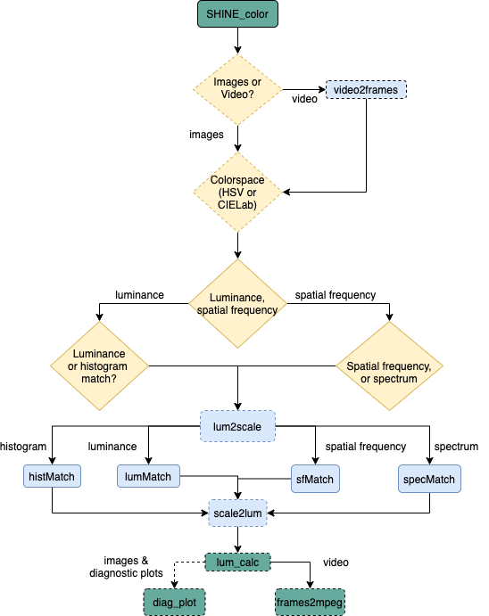

SHINE_color condensed flowchart. Functions (rounded rectangle) and decisions (diamonds) with dashed borders are introduced by SHINE_color (e.g., `video2frames`, `lum2scale`, `scale2lum`, `lum_calc`, `diag_plot`, `frames2mpeg`). They allow SHINE operations to be performed on colorful images.

SHINE_color automatically calculates the mean and standard deviation of the luminance channel before and after manipulations for both images and videos. These statistics are saved in a `.txt` file in the folder `SHINE_color_OUTPUT/DIAGNOSTICS`. In addition, for images, but not for videos, users can choose to generate diagnostic plots of luminance histogram, spatial frequency, or spectra, to compare these properties before and after manipulations. When working with RGB, statistics and plots are generated for each channel. Finally, SHINE_color will automatically save a log of users’ commands in a `.txt` file, allowing users to review their steps across different interactions with the toolbox.

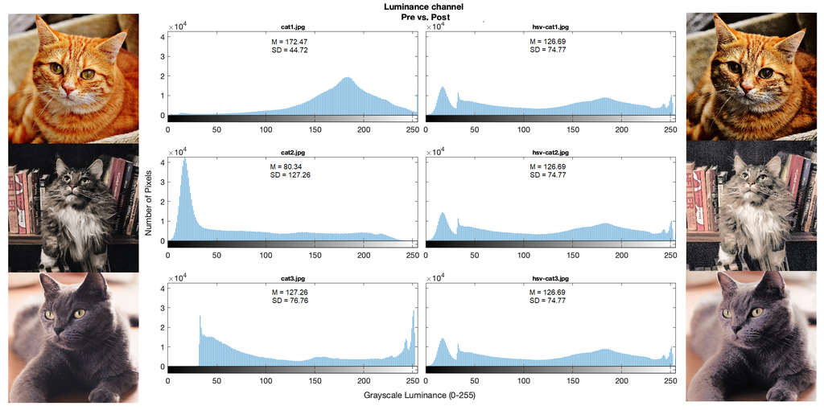

An example of the histogram matching by SHINE_color using the HSV color space. On the left there are images (from pexels), luminance histograms, and summary statistics before the operation. On the right, we have the same elements after the operation.

Table 1. Overview of the functions from SHINE_color. Most functions come from the SHINE toolbox, and their descriptions are also available on Willenbockel et al. (2010). Single stars (*) denotes functions that have been adapted from SHINE, double stars (**) indicates new functions from SHINE_color. Functions are listed in alphabetical order.

| Function | Description |
| --- | --- |
| avgHist | computes average histogram |
| diag_plot** | creates diagnostics plots for manipulated images (luminance histogram, sfPlot, spectrumPlot) |
| frames2mpeg** | creates a mpeg (.mp4) video from a sequence of frames |
| getAllFilesInFolder** | read all frames from a folder |
| getRMSE | computes root mean square error |
| hist2list | transforms histogram into a sorted (darker-to-brigther) list |
| histMatch | exact histogram matching across images |
| imstats | computes image statistics |
| lum2scale** | converts RGB to HSV or CIELab color spaces, extracts the luminance channel, and scale it to grayscale range |
| lum_calc** | computes the luminance channel average and standard deviation |
| lumMatch | scales mean luminance and contrast |
| match | histogram specification |
| readImages* | read input images and apply the lum2scale function (see below) |
| rescale | luminance rescaling |
| scale2lum** | scales the luminance channel (either V channel from HSV, or L channel from CIELab) from grayscale range to HSV or CIELab range |
| separate | foreground-background segregation |
| sfMatch | equates the rotational average of the amplitude spectra |
| sfPlot | plots the energy at each spatial frequency |
| SHINE_color* | main function for loading, equating, and saving grayscale and colorful images |
| specMatch | matches amplitude spectrum |
| spectrumPlot | plots amplitude spectrum |
| ssim_index | computes Structural Similarity index |
| ssim_sens | computes SSIM gradient |
| tarhist | computes a target histogram |
| video2frames** | extracts all frames from a video |

Whereas SHINE_color takes full advantage of the powerful functions from the SHINE toolbox (Willenbockel et al. 2010) for controlling low-level properties of colorful images and videos, it is worth noting that the accurate display of SHINE_color output for experimental research ultimately depends on several factors. Of particular importance are the assumption of linearity between the manipulated luminance values and the display luminance. For isntance, monitor calibration (Willenbockel et al. 2010) and room lightning conditions (Tsukahara and Engle 2020) are essential aspects of this assumption.

The SHINE_color toolbox is openly available at [OSF](https://osf.io/auzjy/) and [GitHub](https://github.com/RodDalBen/SHINE_color). Plans for future development include a MATLAB guided user interface and an adaptation to Python language, for integration with experimental packages such as PsychoPy (Peirce et al. 2019).

# Acknowledgments

I am thankful for my former supervisors, Jessica Hay, Ph.D., Debora de Hollanda Souza, Ph.D., and Krista Byers-Heinlein, Ph.D., for their support. This work was partially funded by grants from FAPESP (#2015/26389-7, #2018/04226-7) and CAPES (#001). The funders had no role in study design, data collection, analysis and interpretation of the data, decision to publish, or preparation of the manuscript.

# References

Cheng, Chen, Zsuzsa Kaldy, and Erik Blaser. 2019. “Focused attention predicts visual working memory performance in 13-month-old infants: A pupillometric study.” *Developmental Cognitive Neuroscience* 36 (January): 100616. https://doi.org/10.1016/j.dcn.2019.100616.

Hepach, Robert, and Gert Westermann. 2016. “Pupillometry in Infancy Research.” *Journal of Cognition and Development* 17 (3): 359–77. https://doi.org/10.1080/15248372.2015.1135801.

Lawson, Rebecca P., Christoph Mathys, and Geraint Rees. 2017. “Adults with autism overestimate the volatility of the sensory environment.” *Nature Neuroscience* 20 (9): 1293–99. https://doi.org/10.1038/nn.4615.

Leung, Tiffany S., Sarah E. Maylott, Guangyu Zeng, Diana N. Nascimben, Krisztina V. Jakobsen, and Elizabeth A. Simpson. 2023. “Behavioral and Physiological Sensitivity to Natural Sick Faces.” *Brain, Behavior, and Immunity* 110: 195–211. https://doi.org/https://doi.org/10.1016/j.bbi.2023.03.007.

Madore, Kevin P., Anna M. Khazenzon, Cameron W. Backes, Jiefeng Jiang, Melina R. Uncapher, Anthony M. Norcia, and Anthony D. Wagner. 2020. “Memory Failure Predicted by Attention Lapsing and Media Multitasking.” *Nature* 587 (7832): 87–91. https://doi.org/10.1038/s41586-020-2870-z.

Peirce, Jonathan, Jeremy R. Gray, Sol Simpson, Michael MacAskill, Richard Höchenberger, Hiroyuki Sogo, Erik Kastman, and Jonas Kristoffer Lindeløv. 2019. “PsychoPy2: Experiments in behavior made easy.” *Behavior Research Methods* 51 (1): 195–203. https://doi.org/10.3758/s13428-018-01193-y.

Rodger, Helen, Luca Vizioli, Xinyi Ouyang, and Roberto Caldara. 2015. “Mapping the development of facial expression recognition.” *Developmental Science* 18 (6): 926–39. https://doi.org/10.1111/desc.12281.

Ruedeerat. 2018. “RGBshine,” February. https://github.com/Ruedeerat/RGBshine.

Tsukahara, Jason S., and Randall W. Engle. 2020. “Is baseline pupil size related to cognitive ability? Yes (under proper lighting conditions).” *Cognition* 211 (March): 104643. https://doi.org/10.1016/j.cognition.2021.104643.

Willenbockel, Verena, Javid Sadr, Daniel Fiset, Greg O. Horne, Frédéric Gosselin, and James W. Tanaka. 2010. “Controlling low-level image properties: The SHINE toolbox.” *Behavior Research Methods* 42 (3): 671–84. https://doi.org/10.3758/BRM.42.3.671.

Zhang, Felicia, Sagi Jaffe-Dax, Robert C. Wilson, and Lauren L. Emberson. 2019. “Prediction in infants and adults: A pupillometry study.” *Developmental Science* 22 (4): 1–9. https://doi.org/10.1111/desc.12780.